# Conditional deviance thresholds for a Poisson power-law spectrum

Companion code for *Conditional Hypothesis Testing on Low Count Poisson Data*.

Under $H_0$, $N_i \sim \mathrm{Poisson}(\alpha x_i^{-\beta})$ independently over $n = 100$ energy bins. The sufficient statistics are $T_1 = \sum_i N_i$ and $T_2 = \sum_i N_i \log x_i$; conditioning on them gives a law free of $(\alpha,\beta)$, and this notebook computes the 95th percentile of the deviance under that law by double saddlepoint, then checks it against simulation.

**Reading order.** Sections run top to bottom with no forward dependencies. Chunks named `fig-*` compute a number quoted in the report and do nothing else; chunks named `plot-*` draw and compute nothing. Everything else defines the machinery those two use.

**Figure manifest.** Each number in the report traces to one chunk:

| Report location | Chunk |
| --- | --- |
| Simulation design: $\Lambda$, per-bin regime, covariate grid | `fig-regime` |
| `rem:cash-numerics`: identity residuals | `fig-identities` |
| Marginal 95% threshold | `fig-marginal` |
| `rem:zeta-zero`: range of $\hat\zeta$ at the root | `fig-saddle-domain` |
| `rem:truncation`: tilted mass at $N_{\max}$, $N_{\max}$ sensitivity | `fig-saddle-domain`, `fig-nmax` |
| `sec:saddle-algorithm`, `app:compute`: ms per fit point | `fig-timing` |
| Abstract, §1.3, exceedance: overall rate and denominator | `fig-exceedance` |
| §1.3: where the conditional surface sits relative to the marginal | `fig-crossing` |
| Per-point calibration | `fig-strip-exceedance` |
| Comparison of the two surfaces: residuals | `fig-residual` |
| Comparison of the two surfaces: per-panel agreement | `fig-panels` |
| Tail-densified per-panel agreement | `fig-panels-boot` |
| Bottom line: conditional vs marginal vs $\chi^2$; threshold correlates with $\Lambda$ and with expected non-empty bins | fig-critical-comparison |
| §6.1: span diagnostic, singular spectra and cliff depths | `fig-span-spectrum` |

**Reproducibility.** Three independent seeded generators are used, one per purpose, so that re-running or reordering any one chunk leaves the others’ numbers unchanged.

```r
library(reticulate)

ENV  <- "power-law-rmd"
PKGS <- c("numpy", "scipy", "matplotlib")

# Named virtualenv rather than an ephemeral one: deterministic across sessions,
# and independent of whether Python has already initialised. cache=FALSE is
# essential -- a cached environment chunk is a chunk that never runs.
if (!virtualenv_exists(ENV)) virtualenv_create(ENV, packages = PKGS)
use_virtualenv(ENV, required = TRUE)

py_config()      # confirms which interpreter actually bound
```

```
#> python:         /Users/michael/.virtualenvs/power-law-rmd/bin/python
#> libpython:      /Library/Frameworks/Python.framework/Versions/3.14/lib/python3.14/config-3.14-darwin/libpython3.14.dylib
#> pythonhome:     /Users/michael/.virtualenvs/power-law-rmd:/Users/michael/.virtualenvs/power-law-rmd
#> version:        3.14.3 (v3.14.3:323c59a5e34, Feb  3 2026, 11:41:37) [Clang 16.0.0 (clang-1600.0.26.6)]
#> numpy:          /Users/michael/.virtualenvs/power-law-rmd/lib/python3.14/site-packages/numpy
#> numpy_version:  2.5.2
#>
#> NOTE: Python version was forced by use_python() function
```

```r
knitr::opts_chunk$set(cache = FALSE, comment = "#>")
```

# 1 Environment

```python
import time
import numpy as np
from scipy.stats import norm, binom, chi2
from scipy.special import gammaln, logsumexp, xlogy
from scipy.interpolate import RegularGridInterpolator
from scipy.optimize import root, brentq
import matplotlib.pyplot as plt

SEED_SIM, SEED_BOOT, SEED_VIEW = 20250805, 20250806, 20250807
rng_sim  = np.random.default_rng(SEED_SIM)    # null datasets
rng_boot = np.random.default_rng(SEED_BOOT)   # tail densification
rng_view = np.random.default_rng(SEED_VIEW)   # plotting subsamples only
```

# 2 Design

The covariate grid is a `ppoints` grid on $[0,1]$ mapped affinely onto $[X_{\min},\, X_{\min}+X_{\mathrm{span}}]$. `ppoints(n)` returns $(i-a)/(n+1-2a)$ with $a = 1/2$ for $n > 10$, so the $x_i$ are the midpoints of $n$ equal subintervals and are pairwise distinct — which is what makes $\ell = \log x$ independent of $\mathbf 1$ and hence $p = 2$.

The rates are **not** normalised: `sample` draws from $\alpha^\star x^{-\beta^\star}$ directly. `fig-regime` reports the resulting count regime.

```python
N_BINS, X_MIN, X_SPAN = 100, 0.4, 3.0
ALPHA_STAR, BETA_STAR = 1.0, 2.0

def ppoints(n, a=None):
    a = (3/8 if n <= 10 else 1/2) if a is None else a
    return (np.arange(1, n + 1) - a) / (n + 1 - 2*a)

x_is = ppoints(N_BINS) * X_SPAN + X_MIN
ell  = np.log(x_is)                    # precomputed once; used by every fit below

def mu_of(alpha, beta):
    """Fitted means. One definition, used everywhere, so no float drift between
    x**-b and exp(-b*log x)."""
    alpha = np.atleast_1d(np.asarray(alpha, float))[:, None]
    beta  = np.atleast_1d(np.asarray(beta,  float))[:, None]
    return np.squeeze(alpha * np.exp(-beta * ell))

mu_star = mu_of(ALPHA_STAR, BETA_STAR)

def sample(m, alpha=ALPHA_STAR, beta=BETA_STAR, rng=None):
    """m datasets of N_BINS counts each, drawn in a single call."""
    rng = rng_sim if rng is None else rng
    return rng.poisson(mu_of(alpha, beta), size=(m, N_BINS))
```

```python
def regime_summary(mu):
    return dict(n_bins=mu.size, x_lo=x_is.min(), x_hi=x_is.max(),
                Lambda=mu.sum(), mu_mean=mu.mean(),
                mu_max=mu.max(), mu_min=mu.min(),
                bins_below_one=int((mu < 1).sum()),
                mean_p_zero=float(np.exp(-mu).mean()))

for k, v in regime_summary(mu_star).items():
    print(f"{k:>16}: {v:.4f}" if isinstance(v, float) else f"{k:>16}: {v}")
```

```
#>           n_bins: 100
#>             x_lo: 0.4150
#>             x_hi: 3.3850
#>           Lambda: 73.4905
#>          mu_mean: 0.7349
#>           mu_max: 5.8064
#>           mu_min: 0.0873
#>   bins_below_one: 80
#>      mean_p_zero: 0.6391
```

# 3 Test statistics

Three statistics, differing only in which data-dependent, parameter-free terms they retain. `cash` drops $\sum_i \log\Gamma(N_i+1)$; `cash_full` keeps it; `deviance` is `cash_full` minus the saturated model, so the $\log\Gamma$ terms cancel. `xlogy` supplies the $0\log 0 = 0$ convention.

```python
def _block(N, alpha_hat, beta_hat):
    N = np.atleast_2d(np.asarray(N, float))
    mu = mu_of(np.atleast_1d(alpha_hat), np.atleast_1d(beta_hat))
    return N, mu.reshape(N.shape[0], -1)

def cash(N, alpha_hat, beta_hat):
    """C: Cash's statistic, factorial term discarded."""
    N, mu = _block(N, alpha_hat, beta_hat)
    return np.squeeze(2 * (mu - xlogy(N, mu)).sum(1))

def cash_full(N, alpha_hat, beta_hat):
    """C_full: twice the negative maximised log-likelihood."""
    N, mu = _block(N, alpha_hat, beta_hat)
    return np.squeeze(2 * (mu - xlogy(N, mu) + gammaln(N + 1)).sum(1))

def cash_saturated(N):
    N = np.atleast_2d(np.asarray(N, float))
    return np.squeeze(2 * (N - xlogy(N, N) + gammaln(N + 1)).sum(1))

def deviance(N, alpha_hat, beta_hat):
    """D = C_full - C_sat, formed directly."""
    N, mu = _block(N, alpha_hat, beta_hat)
    return np.squeeze(2 * (mu - N + xlogy(N, N) - xlogy(N, mu)).sum(1))

def sufficient(N):
    """(T1, T2) = (sum N_i, sum N_i log x_i). No fitting required."""
    N = np.atleast_2d(np.asarray(N, float))
    return N.sum(1), (N * ell).sum(1)
```

# 4 Maximum likelihood

$\hat\beta$ solves $g(\hat\beta) = r$ with

$$g(\beta) = \frac{\sum_i
x_i^{-\beta}\ell_i}{\sum_i x_i^{-\beta}}, \qquad
r = \frac{T_2}{T_1},$$

so $g$ is a weighted mean of $\ell$ with weights $x^{-\beta}$ and $g' = -\operatorname{Var}_w(\ell) < 0$: strictly decreasing, hence invertible. Bracketing by interpolating $g^{-1}$ on a fixed grid and then running vectorised Newton turns 50,000 independent root solves into one interpolation plus a few sweeps over the whole block. $\hat\alpha$ follows in closed form.

```python
_BGRID = np.linspace(-2.0, 8.0, 400)
_W = np.exp(-np.outer(_BGRID, ell))
_G = (_W * ell).sum(1) / _W.sum(1)                 # monotone decreasing

def fit_all(N, iters=6):
    """Joint (alpha, beta) MLEs for every row of N. Agrees with fsolve to ~1e-13."""
    N = np.atleast_2d(np.asarray(N, float))
    S = N.sum(1)
    if np.any(S == 0):
        raise ValueError("dataset with zero total counts: MLE undefined")
    r = (N * ell).sum(1) / S
    b = np.interp(-r, -_G, _BGRID)                 # bracket by inverting g
    for _ in range(iters):                         # vectorised Newton on g(b) - r
        W  = np.exp(-b[:, None] * ell)
        Wt = W.sum(1)
        m1 = (W * ell).sum(1) / Wt
        m2 = (W * ell**2).sum(1) / Wt
        b  = b + (m1 - r) / np.maximum(m2 - m1**2, 1e-12)
    a = S / np.exp(-b[:, None] * ell).sum(1)       # profile alpha
    return a, b
```

```python
example = sample(1)[0]
ex_a, ex_b = (v[0] for v in fit_all(example))
print(f"example dataset: total {int(example.sum())}, "
      f"alpha_hat {ex_a:.4f}, beta_hat {ex_b:.4f}, "
      f"deviance {float(deviance(example, ex_a, ex_b)):.3f}")
```

```
#> example dataset: total 64, alpha_hat 0.8725, beta_hat 1.9905, deviance 74.524
```

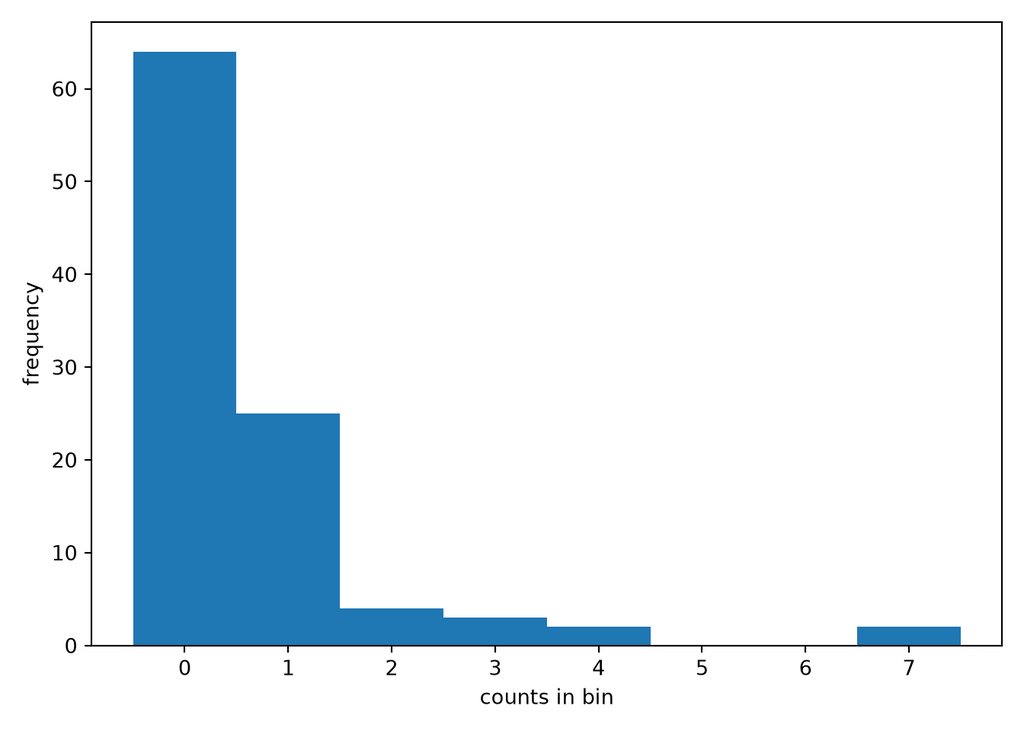

```python
plt.close("all")
plt.hist(example, bins=np.arange(example.max() + 2) - 0.5)
plt.xlabel("counts in bin"); plt.ylabel("frequency")
plt.tight_layout(); plt.show()
```

# 5 Conditional decomposition of the three statistics

Checks the identities of the report’s §3. With $o = 0$ and $z^{(1)} = \mathbf 1$ the reducible-offset condition holds, so $C$ collapses to a function of $t$ alone and $D$ retains only $2\sum_i N_i\log N_i$:

$$C = c(t), \qquad D = c(t) - 2t_1 +
2\sum_i N_i \log N_i,
\qquad c(t) = 2\Big[\textstyle\sum_i\hat\mu_i - \hat\eta_1 t_1 -
\hat\eta_2 t_2\Big],$$

with $(\hat\eta_1,\hat\eta_2) = (\log\hat\alpha,\, -\hat\beta)$. The score identity $T_k = \sum_i \hat\mu_i z_i^{(k)}$ is checked on the same draws; it is what places the denominator saddlepoint at the origin below.

```python
def identity_residuals(n_total, block=25000, seed=SEED_SIM + 1):
    """Max absolute discrepancy in the Section 3 identities and the score identity."""
    rng = np.random.default_rng(seed)
    worst = dict(cash_eq=0.0, dev_eq=0.0, dev_direct=0.0, score_T1=0.0, score_T2=0.0)
    done = 0
    while done < n_total:
        m = min(block, n_total - done)
        N = sample(m, rng=rng).astype(float)
        a, b = fit_all(N)
        mu = mu_of(a, b)
        t1, t2 = sufficient(N)
        c_t = 2 * (mu.sum(1) - np.log(a)*t1 + b*t2)
        C   = cash(N, a, b)
        D   = cash_full(N, a, b) - cash_saturated(N)
        worst["cash_eq"]    = max(worst["cash_eq"], np.abs(C - c_t).max())
        worst["dev_eq"]     = max(worst["dev_eq"],
                                  np.abs(D - (c_t - 2*t1 + 2*xlogy(N, N).sum(1))).max())
        worst["dev_direct"] = max(worst["dev_direct"], np.abs(D - deviance(N, a, b)).max())
        worst["score_T1"]   = max(worst["score_T1"], np.abs(t1 - mu.sum(1)).max())
        worst["score_T2"]   = max(worst["score_T2"], np.abs(t2 - (mu*ell).sum(1)).max())
        done += m
    return n_total, worst

n_checked, res = identity_residuals(200_000)
print(f"datasets checked: {n_checked}")
```

```
#> datasets checked: 200000
```

```python
for k, v in res.items():
    print(f"{k:>12}: {v:.3e}")
```

```
#>      cash_eq: 1.137e-13
#>       dev_eq: 1.279e-13
#>   dev_direct: 1.137e-13
#>     score_T1: 7.105e-14
#>     score_T2: 2.842e-14
```

# 6 Null simulation

```python
N_SIMS = 50_000
datasets = sample(N_SIMS)
alphas, betas = fit_all(datasets)
devs = deviance(datasets, alphas, betas)
```

```python
marg_thresh = np.quantile(devs, 0.95)
print(f"marginal 95% deviance threshold: {marg_thresh:.3f}  (over {N_SIMS} datasets)")
```

```
#> marginal 95% deviance threshold: 96.949  (over 50000 datasets)
```

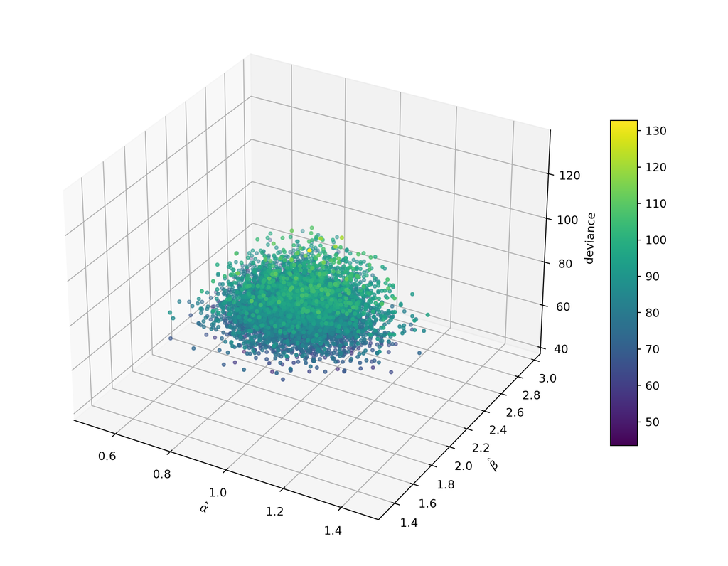

```python
view_idx = rng_view.choice(N_SIMS, 8000, replace=False)   # 50k points is unreadable

plt.close("all")
fig = plt.figure(figsize=(9, 7))
ax = fig.add_subplot(111, projection="3d")
p = ax.scatter(alphas[view_idx], betas[view_idx], devs[view_idx],
               c=devs[view_idx], cmap="viridis", s=8)
ax.set_xlabel(r"$\hat\alpha$"); ax.set_ylabel(r"$\hat\beta$"); ax.set_zlabel("deviance")
fig.colorbar(p, shrink=0.6, aspect=12)
plt.tight_layout(); plt.show()
```

# 7 The double saddlepoint

`_KgH` evaluates the joint CGF of $(D, T)$ under $N_i \sim \mathrm{Poisson}(\hat\mu_i)$ together with its gradient and Hessian, in one pass over the $(N_{\max}+1)\times n$ array of tilted weights. `_Cache` shares that single evaluation between the root-finder’s residual and its Jacobian; handing them in as separate closures doubles the cost of every Newton iteration.

The denominator needs no root solve: because $\hat\mu$ satisfies the score identity, $\nabla K_T(0) = t$, so the denominator saddlepoint sits at the origin and its Hessian is $Z^\top\mathrm{diag}(\hat\mu)Z$ in closed form (`Htt`).

The series converges iff $\zeta < 1/2$ (or $\zeta = 1/2$ with all tilts negative); `NMAX` truncates it, and `fig-saddle-domain` reports both how far $\hat\zeta$ sits from the boundary and how much tilted mass reaches the truncation atom.

```python
NMAX = 70

def _KgH(params, mu, nmax=NMAX):
    """K, grad K, Hess K and the tilted per-bin weights, from one pass."""
    n   = np.arange(nmax + 1)
    lgn = gammaln(n + 1)
    nln = np.where(n > 0, n * np.log(np.maximum(n, 1)), 0.0)
    zeta, tau1, tau2 = params
    lmu = np.log(mu)
    d = 2.0 * (mu[None, :] - n[:, None] + nln[:, None] - n[:, None]*lmu[None, :])
    theta = tau1 + tau2 * ell
    L = (n[:, None]*lmu[None, :] - lgn[:, None] - mu[None, :]
         + zeta*d + theta[None, :]*n[:, None])
    Ki = logsumexp(L, axis=0)
    q  = np.exp(L - Ki[None, :])
    Ec = (q*d).sum(0);              En = (q*n[:, None]).sum(0)
    Vc = (q*d*d).sum(0) - Ec**2;    Vn = (q*(n**2)[:, None]).sum(0) - En**2
    Ccn = (q*d*n[:, None]).sum(0) - Ec*En
    grad = np.array([Ec.sum(), En.sum(), (En*ell).sum()])
    H = np.array([[Vc.sum(),         Ccn.sum(),        (Ccn*ell).sum()],
                  [Ccn.sum(),        Vn.sum(),         (Vn*ell).sum()],
                  [(Ccn*ell).sum(),  (Vn*ell).sum(),   (Vn*ell**2).sum()]])
    return Ki.sum(), grad, H, q

class _Cache:
    """One _KgH evaluation shared between the residual and the Jacobian."""
    def __init__(self, mu, nmax=NMAX):
        self.mu, self.nmax, self.key, self.val = mu, nmax, None, None
    def __call__(self, p):
        k = tuple(np.asarray(p, float))
        if k != self.key:
            self.key, self.val = k, _KgH(np.asarray(p, float), self.mu, self.nmax)
        return self.val

def _cond_cdf(dval, mu, t1, t2, warm, cache):
    """Skovgaard's double-saddlepoint conditional CDF at d, given (t1, t2)."""
    tgt = np.array([dval, t1, t2])
    sol = root(lambda p: cache(p)[1] - tgt, x0=warm,
               jac=lambda p: cache(p)[2], tol=1e-10)
    if not sol.success:
        return np.nan, warm
    zh = sol.x[0]
    Kh, _, Hh, _ = cache(sol.x)
    Htt = np.array([[mu.sum(),        (mu*ell).sum()],
                    [(mu*ell).sum(),  (mu*ell**2).sum()]])   # denominator at the origin
    warg = 2.0*(zh*dval + sol.x[1]*t1 + sol.x[2]*t2 - Kh)
    dr   = np.linalg.det(Hh) / np.linalg.det(Htt)
    if warg <= 0 or dr <= 0:
        return np.nan, sol.x
    w = np.sign(zh)*np.sqrt(warg)
    u = zh*np.sqrt(dr)
    if abs(w) < 1e-7:
        return 0.5, sol.x          # removable singularity; third-cumulant term dropped
    return norm.cdf(w) + norm.pdf(w)*(1/w - 1/u), sol.x

def cond_moments(mu, nmax=NMAX):
    """Conditional mean and sd of D at the fitted point, read off K at the origin."""
    _, g0, H0, _ = _KgH(np.zeros(3), mu, nmax)
    Htt, Hct = H0[1:, 1:], H0[0, 1:]
    return g0[0], np.sqrt(max(H0[0, 0] - Hct @ np.linalg.solve(Htt, Hct), 1e-6))
```

```python
def q_deviance(alpha_hat, beta_hat, q=0.95, warm0=None, nmax=NMAX, xtol=1e-2):
    """Conditional q-quantile of D at a fitted point.

    Returns (threshold, tilt at the root). The tilt is refreshed at the root
    before returning: the last bracketing solve is NOT the saddlepoint of
    interest, and reading zeta_hat off it understates it.
    Threshold resolved to `xtol`, well inside the empirical CI widths below.
    """
    mu = np.atleast_1d(mu_of(alpha_hat, beta_hat)).ravel()
    t1, t2 = mu.sum(), (mu*ell).sum()
    cache = _Cache(mu, nmax)
    Emean, cond_sd = cond_moments(mu, nmax)

    warm = np.zeros(3) if warm0 is None else np.asarray(warm0, float)
    d    = Emean + norm.ppf(q)*cond_sd          # start at the normal approximation
    step = max(0.15, 0.5*cond_sd)

    F, warm = _cond_cdf(d, mu, t1, t2, warm, cache)
    if not np.isfinite(F):
        return np.nan, warm
    if F < q:
        lo = d
        for _ in range(60):
            d += step; F, warm = _cond_cdf(d, mu, t1, t2, warm, cache)
            if not np.isfinite(F): return lo, warm      # CGF edge; lower bound
            if F >= q: break
            lo = d
        hi = d
    else:
        hi = d
        for _ in range(60):
            d -= step; F, warm = _cond_cdf(d, mu, t1, t2, warm, cache)
            if not np.isfinite(F) or F < q: break
            hi = d
        lo = d

    thr = brentq(lambda x: _cond_cdf(x, mu, t1, t2, warm, cache)[0] - q, lo, hi, xtol=xtol)
    _, warm = _cond_cdf(thr, mu, t1, t2, warm, cache)
    return thr, warm

def q_surface(alpha_grid, beta_grid, q=0.95):
    """Threshold surface; warm-started along each beta row."""
    AA, BB = np.meshgrid(alpha_grid, beta_grid)
    Q = np.full(AA.shape, np.nan)
    for i in range(AA.shape[0]):
        warm = None
        for j in range(AA.shape[1]):
            Q[i, j], warm = q_deviance(AA[i, j], BB[i, j], q=q, warm0=warm)
    return AA, BB, Q

def theory_curve(alpha_grid, beta, q=0.95):
    """Pointwise thresholds along alpha at fixed beta, warm-started."""
    warm, out = None, []
    for a in alpha_grid:
        v, warm = q_deviance(a, beta, q=q, warm0=warm)
        out.append(v)
    return np.asarray(out)
```

## 7.1 Diagnostics

```python
def saddle_domain_report(alphas, betas, q=0.95, probs=(0.02, 0.50, 0.98)):
    rows = []
    for pa in probs:
        for pb in probs:
            a, b = np.quantile(alphas, pa), np.quantile(betas, pb)
            thr, warm = q_deviance(a, b, q=q)
            mu = np.atleast_1d(mu_of(a, b)).ravel()
            _, _, _, w = _KgH(warm, mu)
            rows.append((a, b, thr, warm[0], float(w[-1, :].max())))
    return rows

rows = saddle_domain_report(alphas, betas)
print(f"{'alpha':>7}{'beta':>7}{'thr':>9}{'zeta_hat':>10}{'mass@NMAX':>12}")
```

```
#>   alpha   beta      thr  zeta_hat   mass@NMAX
```

```python
for a, b, thr, z, m in rows:
    print(f"{a:7.3f}{b:7.3f}{thr:9.2f}{z:10.4f}{m:12.2e}")
```

```
#>   0.743  1.592    93.85    0.1659    6.78e-45
#>   0.743  2.002    86.20    0.1611    2.60e-38
#>   0.743  2.471    78.66    0.1542    3.35e-31
#>   0.990  1.592   102.67    0.1478    9.60e-42
#>   0.990  2.002    94.38    0.1465    1.35e-34
#>   0.990  2.471    85.99    0.1429    4.98e-27
#>   1.255  1.592   109.42    0.1357    1.67e-38
#>   1.255  2.002   100.87    0.1367    4.38e-31
#>   1.255  2.471    91.98    0.1353    2.37e-23
```

```python
zs = [r[3] for r in rows]
print(f"\nzeta_hat at q=0.95 in [{min(zs):.4f}, {max(zs):.4f}]   (domain boundary 0.5)")
```

```
#>
#> zeta_hat at q=0.95 in [0.1353, 0.1659]   (domain boundary 0.5)
```

```python
print(f"max tilted mass on the truncation atom: {max(r[4] for r in rows):.2e}")
```

```
#> max tilted mass on the truncation atom: 2.37e-23
```

```python
for nm in (40, 55, 70, 90, 120):
    print(f"NMAX={nm:4d}  threshold at (alpha,beta)=(1,2): "
          f"{q_deviance(1.0, 2.0, nmax=nm)[0]:.3f}")
```

```
#> NMAX=  40  threshold at (alpha,beta)=(1,2): 94.709
#> NMAX=  55  threshold at (alpha,beta)=(1,2): 94.709
#> NMAX=  70  threshold at (alpha,beta)=(1,2): 94.709
#> NMAX=  90  threshold at (alpha,beta)=(1,2): 94.709
#> NMAX= 120  threshold at (alpha,beta)=(1,2): 94.709
```

```python
def timing_ms(alpha_grid, beta_value):
    t0, warm = time.perf_counter(), None
    for a in alpha_grid:
        _, warm = q_deviance(a, beta_value, warm0=warm)
    return 1000*(time.perf_counter() - t0)/len(alpha_grid)

print(f"{timing_ms(np.linspace(0.8, 1.2, 24), 2.0):.0f} ms per fit point "
      f"(warm-started along a 24-point row)")
```

```
#> 42 ms per fit point (warm-started along a 24-point row)
```

# 8 Threshold surface and exceedance

The surface is tabulated on the central 96% of each fitted marginal, then interpolated to every simulated fit. Fits outside that rectangle have no tabulated threshold and are excluded — the exceedance denominator is the number retained, not `N_SIMS`, and both are reported.

```python
GRID_N = 24
alpha_axis = np.linspace(*np.quantile(alphas, [0.02, 0.98]), GRID_N)
beta_axis  = np.linspace(*np.quantile(betas,  [0.02, 0.98]), GRID_N)
_, _, Z_surface = q_surface(alpha_axis, beta_axis)      # rows = beta, cols = alpha

interp = RegularGridInterpolator((beta_axis, alpha_axis), Z_surface,
                                 bounds_error=False, fill_value=np.nan)
thr_at = interp(np.column_stack([betas, alphas]))
inside = np.isfinite(thr_at)
```

```python
exc = np.mean(devs[inside] > thr_at[inside])
se  = np.sqrt(exc*(1 - exc)/inside.sum())
print(f"exceedance {100*exc:.2f}% +/- {100*se:.2f}%   target 5.00%")
```

```
#> exceedance 4.95% +/- 0.10%   target 5.00%
```

```python
print(f"denominator: {inside.sum()} of {N_SIMS} fits inside the tabulated grid "
      f"({100*inside.mean():.1f}%)")
```

```
#> denominator: 46250 of 50000 fits inside the tabulated grid (92.5%)
```

```python
# The conditional threshold cannot lie below the marginal one everywhere: the
# marginal threshold is an average of the conditional ones, so the surfaces must
# cross. This reports where on the tabulated grid each side holds.
below = np.nanmean(Z_surface < marg_thresh)
print(f"marginal 95% threshold: {marg_thresh:.2f}")
```

```
#> marginal 95% threshold: 96.95
```

```python
print(f"conditional surface range: [{np.nanmin(Z_surface):.2f}, {np.nanmax(Z_surface):.2f}]")
```

```
#> conditional surface range: [78.66, 109.42]
```

```python
print(f"grid fraction with conditional threshold BELOW marginal: {100*below:.1f}%")
```

```
#> grid fraction with conditional threshold BELOW marginal: 67.4%
```

# 9 Empirical conditional thresholds

MLEs are continuous, so they cannot be grouped by equality; they are binned into quantile strips and the 95th percentile taken within each. `strip_quantile` returns an order-statistic point estimate with a binomial confidence interval, so the theory curve can be judged against sampling error rather than against a bare point.

```python
MIN_PER_STRIP = 50          # sparse strips give unreliable 95th percentiles
N_CELLS       = 10

def strip_quantile(g, p=0.95, conf=0.95):
    """Order-statistic point estimate and CI for the p-quantile of g."""
    n = len(g); s = np.sort(g)
    idx = lambda k: s[min(max(int(k) - 1, 0), n - 1)]
    return (idx(binom.ppf((1 - conf)/2, n, p)),
            idx(np.ceil(p*n)),
            idx(binom.ppf(1 - (1 - conf)/2, n, p)))

a_edges = np.quantile(alphas, np.linspace(0, 1, N_CELLS + 1))
b_edges = np.quantile(betas,  np.linspace(0, 1, N_CELLS + 1))
a_idx = np.clip(np.digitize(alphas, a_edges[1:-1]), 0, N_CELLS - 1)
b_idx = np.clip(np.digitize(betas,  b_edges[1:-1]), 0, N_CELLS - 1)

cell_xy, cell_q, cell_ij = [], [], []
for i in range(N_CELLS):
    for j in range(N_CELLS):
        m = (a_idx == i) & (b_idx == j)
        if m.sum() >= MIN_PER_STRIP:
            cell_xy.append((0.5*(a_edges[i] + a_edges[i+1]),
                            0.5*(b_edges[j] + b_edges[j+1])))
            cell_q.append(np.quantile(devs[m], 0.95))
            cell_ij.append((i, j))          # kept: no searchsorted round-trip later
cell_xy, cell_q, cell_ij = map(np.array, (cell_xy, cell_q, cell_ij))
cell_a, cell_b = cell_xy[:, 0], cell_xy[:, 1]
```

```python
cell_theory = interp(np.column_stack([cell_b, cell_a]))
resid       = cell_q - cell_theory
resid_pct   = 100*resid/cell_theory
print(f"cells: {len(resid)}")
```

```
#> cells: 100
```

```python
print(f"median residual (empirical - theory): {np.nanmedian(resid):+.2f} "
      f"({np.nanmedian(resid_pct):+.1f}% of threshold)")
```

```
#> median residual (empirical - theory): -0.40 (-0.4% of threshold)
```

```python
print(f"residual range: [{np.nanmin(resid):.2f}, {np.nanmax(resid):.2f}]")
```

```
#> residual range: [-2.32, 2.64]
```

```python
rate_cell, cell_n = [], []
for i, j in cell_ij:
    m = (a_idx == i) & (b_idx == j) & np.isfinite(thr_at)
    if m.sum() >= MIN_PER_STRIP:
        rate_cell.append(np.mean(devs[m] > thr_at[m]))
        cell_n.append(int(m.sum()))
rate_cell, cell_n = np.array(rate_cell), np.array(cell_n)

print(f"per-cell exceedance over {len(rate_cell)} cells (target 5.00%):")
```

```
#> per-cell exceedance over 100 cells (target 5.00%):
```

```python
print(f"  median {100*np.median(rate_cell):.2f}%   "
      f"range [{100*rate_cell.min():.2f}%, {100*rate_cell.max():.2f}%]")
```

```
#>   median 4.86%   range [1.92%, 8.01%]
```

```python
print(f"  IQR [{100*np.percentile(rate_cell,25):.2f}%, "
      f"{100*np.percentile(rate_cell,75):.2f}%]")
```

```
#>   IQR [4.08%, 5.85%]
```

```python
print(f"  cell sizes: median {int(np.median(cell_n))}, "
      f"range [{cell_n.min()}, {cell_n.max()}]  "
      f"-> typical binomial SE {100*np.sqrt(0.05*0.95/np.median(cell_n)):.2f}%")
```

```
#>   cell sizes: median 505, range [52, 777]  -> typical binomial SE 0.97%
```

[figure not shown]

```python
Q = np.full((N_CELLS, N_CELLS), np.nan)
for (i, j), v in zip(cell_ij, cell_q):
    Q[j, i] = v

plt.close("all")
plt.figure(figsize=(7, 6))
plt.pcolormesh(a_edges, b_edges, Q, cmap="Reds", shading="flat")
plt.colorbar(label="empirical conditional 95% threshold")
plt.scatter(alphas[view_idx], betas[view_idx], s=1, c="grey", alpha=0.1)
plt.xlabel(r"$\hat\alpha$"); plt.ylabel(r"$\hat\beta$")
plt.tight_layout(); plt.show()
```

# 10 Comparison of the two surfaces

Each panel fixes a band of $\hat\beta$ and walks along $\hat\alpha$. The empirical strip quantile within a cell is a quantile of the deviance *mixed* over that cell’s own $\hat\beta$ values, so the theory curve must be mixed the same way — `theory_mixture` averages the conditional CDFs over representative $\hat\beta$ and inverts. A mixture quantile is bounded by its components’, so the two panel-edge curves bracket the root.

```python
N_BPANELS, N_ASTRIPS, N_BETA_REP = 4, 20, 9
b_cuts  = np.quantile(betas, np.linspace(0, 1, N_BPANELS + 1))
b_panel = np.clip(np.digitize(betas, b_cuts[1:-1]), 0, N_BPANELS - 1)

def theory_mixture(alpha_c, betas_cell, lo, hi, q=0.95, n_rep=N_BETA_REP):
    if betas_cell.size == 0:
        return np.nan
    bq = np.quantile(betas_cell, (np.arange(n_rep) + 0.5)/n_rep)
    comp = []
    for b in bq:
        mu = np.atleast_1d(mu_of(alpha_c, b)).ravel()
        comp.append([mu, mu.sum(), (mu*ell).sum(), _Cache(mu), np.zeros(3)])
    def Fmix(d):
        tot = 0.0
        for c in comp:
            F, w = _cond_cdf(d, c[0], c[1], c[2], c[4], c[3])
            c[4] = w
            tot += 0.0 if not np.isfinite(F) else F
        return tot/n_rep - q
    a, b = lo - 5.0, hi + 5.0
    for _ in range(6):
        if Fmix(a) < 0 < Fmix(b):
            return brentq(Fmix, a, b, xtol=1e-2)
        a -= 10.0; b += 10.0
    return np.nan

def panel_fit(a_sub, b_sub, d_sub, a_edges_p, beta_lo, beta_hi):
    """Empirical strip quantiles with CIs, and the matching mixed theory curve."""
    a_str = np.clip(np.digitize(a_sub, a_edges_p[1:-1]), 0, len(a_edges_p) - 2)
    lx, ly, lo, hi, cells, ns = [], [], [], [], [], []
    for i in range(len(a_edges_p) - 1):
        sel = a_str == i
        g = d_sub[sel]
        if g.size >= MIN_PER_STRIP:
            c0, pt, c1 = strip_quantile(g)
            lx.append(0.5*(a_edges_p[i] + a_edges_p[i+1]))
            ly.append(pt); lo.append(c0); hi.append(c1)
            cells.append(b_sub[sel]); ns.append(g.size)
    if not lx:
        return None
    lx, ly, lo, hi = map(np.asarray, (lx, ly, lo, hi))
    t_lo, t_hi = theory_curve(lx, beta_lo), theory_curve(lx, beta_hi)
    band_lo, band_hi = np.minimum(t_lo, t_hi), np.maximum(t_lo, t_hi)
    t_mix = np.array([theory_mixture(a, bc, l, h)
                      for a, bc, l, h in zip(lx, cells, band_lo, band_hi)])
    ok = np.isfinite(t_mix)
    r  = ly[ok] - t_mix[ok]
    return dict(lx=lx, ly=ly, lo=lo, hi=hi, band_lo=band_lo, band_hi=band_hi,
                t_mix=t_mix, n_strips=int(ok.sum()), min_draws=int(min(ns)),
                inside=float(np.mean((t_mix[ok] >= lo[ok]) & (t_mix[ok] <= hi[ok]))),
                med_resid=float(np.median(r)),
                n_pos=int((r > 0).sum()), n_neg=int((r < 0).sum()),
                med_ci=float(np.median(hi - lo)))

def panel_report(tab, p, extra=""):
    print(f"panel {p}: inside {100*tab['inside']:.0f}% of {tab['n_strips']} strips | "
          f"median resid {tab['med_resid']:+.2f} | "
          f"sign split {tab['n_pos']}+/{tab['n_neg']}- | "
          f"median CI width {tab['med_ci']:.2f}{extra}")

def panel_draw(ax, tab, title, first):
    lab = (lambda s: s if first else None)
    ax.fill_between(tab['lx'], tab['lo'], tab['hi'], color="darkred", alpha=0.15,
                    lw=0, label=lab("empirical 95% CI"))
    ax.plot(tab['lx'], tab['ly'], color="darkred", lw=1.5, marker="o", ms=3,
            label=lab("empirical 95%"))
    ax.fill_between(tab['lx'], tab['band_lo'], tab['band_hi'], color="goldenrod",
                    alpha=0.20, lw=0, label=lab(r"theory across $\hat\beta$ band"))
    ax.plot(tab['lx'], tab['t_mix'], color="darkorange", lw=1.8,
            label=lab(r"theory 95% (mixed over $\hat\beta$)"))
    ax.axhline(marg_thresh, color="black", lw=1.2, ls="--", label=lab("marginal 95%"))
    ax.set_title(title); ax.set_xlabel(r"$\hat\alpha$")
```

```python
panels = []
for p in range(N_BPANELS):
    m = b_panel == p
    edges = np.quantile(alphas[m], np.linspace(0, 1, N_ASTRIPS + 1))
    tab = panel_fit(alphas[m], betas[m], devs[m], edges, b_cuts[p], b_cuts[p+1])
    panels.append((tab, edges, m))
    if tab: panel_report(tab, p)
```

```
#> panel 0: inside 90% of 20 strips | median resid -0.27 | sign split 9+/11- | median CI width 3.36
#> panel 1: inside 80% of 20 strips | median resid +0.26 | sign split 11+/9- | median CI width 3.31
#> panel 2: inside 90% of 20 strips | median resid -0.29 | sign split 7+/13- | median CI width 3.00
#> panel 3: inside 90% of 20 strips | median resid -0.04 | sign split 10+/10- | median CI width 3.11
```

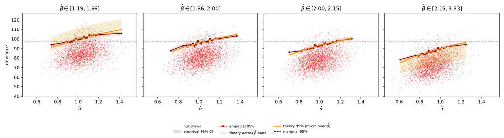

```python
plt.close("all")
fig, axes = plt.subplots(1, N_BPANELS, figsize=(16, 4.4), sharex=True, sharey=True)
for p, ax in enumerate(axes):
    tab, _, m = panels[p]
    thin = rng_view.choice(int(m.sum()), min(int(m.sum()), 3000), replace=False)
    ax.scatter(alphas[m][thin], devs[m][thin], c="red", s=3, marker="+", alpha=0.3,
               label="null draws" if p == 0 else None)
    if tab:
        panel_draw(ax, tab, rf"$\hat\beta \in [{b_cuts[p]:.2f}, {b_cuts[p+1]:.2f}]$", p == 0)
axes[0].set_ylabel("deviance")
h, l = axes[0].get_legend_handles_labels()
fig.legend(h, l, loc="lower center", ncol=3, fontsize=8, frameon=False,
           bbox_to_anchor=(0.5, 0.0))
fig.tight_layout(rect=(0, 0.16, 1, 1)); plt.show()
```

## 10.1 Tail densification

The conditional law of $D$ given $(T_1,T_2)$ does not depend on the true $(\alpha,\beta)$, so draws generated at any truth may be pooled — provided they are compared against a theory curve built from the pooled cell’s own $\hat\beta$ values, which `theory_mixture` already does. This fills the strips of $\hat\alpha$ that the main simulation reaches too rarely.

```python
A_LO, A_HI      = 0.55, 1.65     # wider than the main simulation reaches
N_TARGETS       = 14             # simulation truths per panel
BOOT_PER_TARGET = 6000

a_edges_fix = np.linspace(A_LO, A_HI, N_ASTRIPS + 1)
boot_a, boot_b, boot_d = [], [], []
for p in range(N_BPANELS):
    b_mid = np.median(betas[b_panel == p])
    for at in np.linspace(A_LO, A_HI, N_TARGETS):
        Nb = sample(BOOT_PER_TARGET, alpha=at, beta=b_mid, rng=rng_boot)
        aa, bb = fit_all(Nb)
        keep = (bb >= b_cuts[p]) & (bb < b_cuts[p+1]) & (aa >= A_LO) & (aa < A_HI)
        if keep.any():
            boot_a.append(aa[keep]); boot_b.append(bb[keep])
            boot_d.append(deviance(Nb[keep], aa[keep], bb[keep]))

pool_a = np.concatenate([alphas] + boot_a)
pool_b = np.concatenate([betas]  + boot_b)
pool_d = np.concatenate([devs]   + boot_d)
pool_p = np.clip(np.digitize(pool_b, b_cuts[1:-1]), 0, N_BPANELS - 1)
```

```python
panels_boot = []
for p in range(N_BPANELS):
    m = pool_p == p
    tab = panel_fit(pool_a[m], pool_b[m], pool_d[m], a_edges_fix,
                    b_cuts[p], b_cuts[p+1])
    panels_boot.append((tab, m))
    if tab: panel_report(tab, p, extra=f" | min draws/strip {tab['min_draws']}")
```

```
#> panel 0: inside 95% of 20 strips | median resid -0.05 | sign split 9+/11- | median CI width 1.47 | min draws/strip 1831
#> panel 1: inside 95% of 20 strips | median resid +0.14 | sign split 12+/8- | median CI width 2.28 | min draws/strip 649
#> panel 2: inside 95% of 20 strips | median resid -0.07 | sign split 8+/12- | median CI width 2.24 | min draws/strip 633
#> panel 3: inside 95% of 20 strips | median resid -0.02 | sign split 9+/11- | median CI width 1.47 | min draws/strip 1604
```

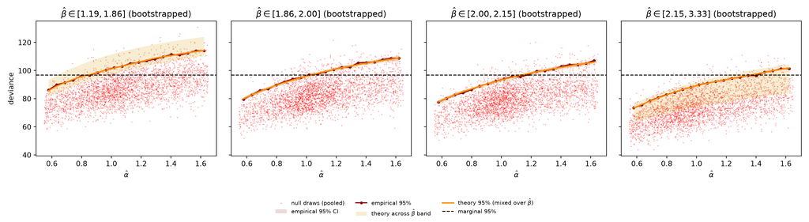

```python
plt.close("all")
fig, axes = plt.subplots(1, N_BPANELS, figsize=(16, 4.4), sharex=True, sharey=True)
for p, ax in enumerate(axes):
    tab, m = panels_boot[p]
    thin = rng_view.choice(int(m.sum()), min(int(m.sum()), 3000), replace=False)
    ax.scatter(pool_a[m][thin], pool_d[m][thin], c="red", s=3, marker="+", alpha=0.3,
               label="null draws (pooled)" if p == 0 else None)
    if tab:
        panel_draw(ax, tab,
                   rf"$\hat\beta \in [{b_cuts[p]:.2f}, {b_cuts[p+1]:.2f}]$ (bootstrapped)",
                   p == 0)
axes[0].set_ylabel("deviance")
h, l = axes[0].get_legend_handles_labels()
fig.legend(h, l, loc="lower center", ncol=3, fontsize=8, frameon=False,
           bbox_to_anchor=(0.5, 0.0))
fig.tight_layout(rect=(0, 0.16, 1, 1)); plt.show()
```

# 11 Three-dimensional views

```r
library(reticulate); library(plotly)
idx    <- py$view_idx + 1                      # Python indices are 0-based
alphas <- py$alphas[idx]
betas  <- py$betas[idx]
devi   <- py$devs[idx]

plot_ly() |>
  add_surface(x = py$alpha_axis, y = py$beta_axis, z = py$Z_surface,
              colorscale = list(c(0, "#08306b"), c(1, "#6baed6")),
              opacity = 0.65, showscale = FALSE, name = "theory (saddlepoint)") |>
  add_trace(type = "mesh3d",
            x = py$cell_a, y = py$cell_b, z = py$cell_q, intensity = py$cell_q,
            colorscale = list(c(0, "#7f2704"), c(1, "#fd8d3c")),
            opacity = 0.85, showscale = FALSE, name = "empirical (per-cell)") |>
  add_markers(x = alphas, y = betas, z = devi,
              marker = list(size = 1.2, color = "grey", opacity = 0.08),
              name = "null draws") |>
  add_surface(x = range(alphas), y = range(betas),
              z = matrix(py$marg_thresh, 2, 2),
              colorscale = list(c(0, "black"), c(1, "black")),
              opacity = 0.12, showscale = FALSE, name = "95% marginal") |>
  layout(scene = list(xaxis = list(title = "alpha_hat"),
                      yaxis = list(title = "beta_hat"),
                      zaxis = list(title = "deviance"),
                      camera = list(eye = list(x = 1.6, y = -1.6, z = 0.9))))
```

[interactive chart not shown]

```r
plot_ly(x = py$cell_a, y = py$cell_b, z = py$resid,
        type = "scatter", mode = "markers",
        marker = list(size = 11, color = py$resid, colorscale = "RdBu",
                      cmid = 0, showscale = TRUE,
                      colorbar = list(title = "empirical - theory"))) |>
  layout(xaxis = list(title = "alpha_hat"),
         yaxis = list(title = "beta_hat"),
         title = "Per-cell fit residual (0 = perfect agreement)")
```

[interactive chart not shown]

# 12 Bottom line: the conditional critical value against its two alternatives

The conditional threshold replaces two fixed critical values: the 95th percentile of the marginal null distribution (the grey plane in the plots above), and the asymptotic $\chi^2_{n-d}$ quantile. This tabulates all three across the fitted region.

The conditional surface cannot lie below the marginal plane everywhere — the marginal threshold is an average of the conditional ones, so the two must cross, and the sign of the comparison is itself the result.

```python
CHI2_Q95 = float(chi2.ppf(0.95, N_BINS - 2))     # asymptotic reference, n - d

def critical_value_table(alpha_probs=(0.05, 0.25, 0.50, 0.75, 0.95),
                         beta_probs=(0.10, 0.50, 0.90), q=0.95):
    """Conditional critical value at fitted points spanning the null distribution
    of (alpha_hat, beta_hat), against the marginal and asymptotic thresholds.
    Warm-started along each beta row."""
    rows = []
    for pb in beta_probs:
        b = float(np.quantile(betas, pb))
        warm = None
        for pa in alpha_probs:
            a = float(np.quantile(alphas, pa))
            thr, warm = q_deviance(a, b, q=q, warm0=warm)
            rows.append((a, b, thr,
                         100*(thr/marg_thresh - 1),
                         100*(thr/CHI2_Q95 - 1)))
    return rows

rows = critical_value_table()
print(f"marginal 95% of the null draws : {marg_thresh:.2f}")
```

```
#> marginal 95% of the null draws : 96.95
```

```python
print(f"chi2_{{{N_BINS - 2}}} 95th percentile      : {CHI2_Q95:.2f}\n")
```

```
#> chi2_{98} 95th percentile      : 122.11
```

```python
print(f"{'alpha_hat':>10}{'beta_hat':>10}{'conditional':>13}"
      f"{'vs marginal':>13}{'vs chi2':>10}")
```

```
#>  alpha_hat  beta_hat  conditional  vs marginal   vs chi2
```

```python
for a, b, thr, d_marg, d_chi in rows:
    print(f"{a:10.3f}{b:10.3f}{thr:13.2f}{d_marg:12.1f}%{d_chi:9.1f}%")
```

```
#>      0.790     1.739        92.87        -4.2%    -23.9%
#>      0.906     1.739        96.99         0.0%    -20.6%
#>      0.990     1.739        99.61         2.7%    -18.4%
#>      1.075     1.739       102.00         5.2%    -16.5%
#>      1.200     1.739       105.08         8.4%    -13.9%
#>      0.790     2.002        87.96        -9.3%    -28.0%
#>      0.906     2.002        91.87        -5.2%    -24.8%
#>      0.990     2.002        94.38        -2.7%    -22.7%
#>      1.075     2.002        96.68        -0.3%    -20.8%
#>      1.200     2.002        99.67         2.8%    -18.4%
#>      0.790     2.286        83.12       -14.3%    -31.9%
#>      0.906     2.286        86.78       -10.5%    -28.9%
#>      0.990     2.286        89.15        -8.0%    -27.0%
#>      1.075     2.286        91.33        -5.8%    -25.2%
#>      1.200     2.286        94.20        -2.8%    -22.9%
```

```python
thr_all  = np.array([r[2] for r in rows])
d_marg   = np.array([r[3] for r in rows])
d_chi    = np.array([r[4] for r in rows])
print(f"\nconditional threshold ranges {thr_all.min():.2f} to {thr_all.max():.2f} "
      f"across the fitted region")
```

```
#>
#> conditional threshold ranges 83.12 to 105.08 across the fitted region
```

```python
print(f"  vs marginal: {d_marg.min():+.1f}% to {d_marg.max():+.1f}%   "
      f"({int((d_marg < 0).sum())} of {len(d_marg)} points below the plane)")
```

```
#>   vs marginal: -14.3% to +8.4%   (10 of 15 points below the plane)
```

```python
print(f"  vs chi2:     {d_chi.min():+.1f}% to {d_chi.max():+.1f}%   "
      f"({int((d_chi < 0).sum())} of {len(d_chi)} points below)")
```

```
#>   vs chi2:     -31.9% to -13.9%   (15 of 15 points below)
```

```python
# What the threshold actually tracks. Lambda is the expected photon count;
# sum_i (1 - exp(-mu_i)) is the expected number of bins recording anything at
# all. A dark bin contributes 2*mu_i to the deviance and almost nothing to its
# variability, so the statistic behaves as though it had fewer components --
# which is why the second correlation is the strong one.
lam     = np.array([mu_of(a, b).sum()               for a, b, *_ in rows])
nonzero = np.array([(1 - np.exp(-mu_of(a, b))).sum() for a, b, *_ in rows])
print(f"\nover the same {len(rows)} points:")
```

```
#>
#> over the same 15 points:
```

```python
print(f"  threshold vs Lambda (expected photons)   : "
      f"r = {np.corrcoef(thr_all, lam)[0, 1]:+.2f}")
```

```
#>   threshold vs Lambda (expected photons)   : r = +0.43
```

```python
print(f"  threshold vs expected non-empty bins     : "
      f"r = {np.corrcoef(thr_all, nonzero)[0, 1]:+.2f}")
```

```
#>   threshold vs expected non-empty bins     : r = +0.96
```

```python
# Numerical test of the span criterion (report Section 6.1).
#
# dim V_0 is a rank, but a rank computed with a tolerance answers the wrong
# question: on a finite grid every model has dim V_0 <= n, so what distinguishes
# a model inside the class from one outside it is not the value of the rank but
# the SHAPE of the singular spectrum. A model in the class has rank exactly p,
# so rho_{p+1} falls to rounding level -- a cliff. A model outside contributes
# derivative directions that shrink but never vanish -- a ramp.
#
# No column scaling is applied: the columns of M are bins, and rescaling them
# would change V_0 itself rather than merely recondition the basis.

from itertools import product

# --- fixed covariate-dependent vectors used by the composite models ----------
X_BREAK = 1.5                                    # held fixed; see ex:scope-broken
_u = (x_is < X_BREAK).astype(float)              # low-energy branch indicator
_v = 1.0 - _u
_w = ell - np.log(X_BREAK)

LINE_CTR, LINE_WID = 1.5, 0.05                   # keV; narrow relative to the grid
_phi = np.exp(-0.5*((x_is - LINE_CTR)/LINE_WID)**2)
_phi /= _phi.max()

# --- log-mean vectors m(theta) ----------------------------------------------
def lm_power_law(a, b):    return np.log(a) - b*ell
def lm_brems(a, kT):       return np.log(a) - ell - x_is/kT
def lm_broken(A, b1, b2):  return np.log(A) - b1*(_u*_w) - b2*(_v*_w)
def lm_blackbody(a, b):    return np.log(a) + 2*ell - np.log(np.expm1(b*x_is))
def lm_pl_line(a, b, A):   return np.log(a*np.exp(-b*ell) + A*_phi)

def span_spectrum(logmu, axes, ref=None):
    """Normalised singular values of the matrix of differences m(theta)-m(theta_0).

    `axes` is a tuple of 1-D parameter grids; the product grid must span the
    region the threshold will be used over. A grid too narrow understates p:
    any smooth model looks flat on a small enough neighbourhood.
    """
    grid = list(product(*axes))
    M = np.array([logmu(*th) for th in grid])
    M = M - (M[len(M)//2] if ref is None else logmu(*ref))
    s = np.linalg.svd(M, compute_uv=False)
    return s/s[0], len(grid)

MODELS = [
    ("power law",            lm_power_law, (np.linspace(0.6, 1.6, 7),
                                            np.linspace(1.4, 2.6, 7)),               2),
    ("bremsstrahlung",       lm_brems,     (np.linspace(0.6, 1.6, 7),
                                            np.linspace(0.5, 3.0, 7)),               2),
    ("broken power law",     lm_broken,    (np.linspace(0.6, 1.6, 5),
                                            np.linspace(1.0, 2.0, 5),
                                            np.linspace(2.0, 3.0, 5)),               3),
    ("blackbody",            lm_blackbody, (np.linspace(0.6, 1.6, 7),
                                            np.linspace(0.5, 3.0, 7)),            None),
    ("power law + line",     lm_pl_line,   (np.linspace(0.6, 1.6, 5),
                                            np.linspace(1.4, 2.6, 5),
                                            np.linspace(0.2, 2.0, 5)),            None),
]

K_SHOW = 8
print(f"normalised singular values rho_k = sigma_k / sigma_1   "
      f"(n = {N_BINS} bins)\n")
```

```
#> normalised singular values rho_k = sigma_k / sigma_1   (n = 100 bins)
```

```python
print(f"{'model':>20}{'J':>5}{'p':>4}   " +
      "".join(f"{'rho_'+str(k+1):>10}" for k in range(K_SHOW)))
```

```
#>                model    J   p        rho_1     rho_2     rho_3     rho_4     rho_5     rho_6     rho_7     rho_8
```

```python
spectra = {}
for name, f, axes, p_expected in MODELS:
    rho, J = span_spectrum(f, axes)
    spectra[name] = rho
    pe = "-" if p_expected is None else str(p_expected)
    print(f"{name:>20}{J:5d}{pe:>4}   " +
          "".join(f"{rho[k]:10.2e}" if k < len(rho) else f"{'':>10}"
                  for k in range(K_SHOW)))
```

```
#>            power law   49   2     1.00e+00  4.37e-01  1.72e-16  1.11e-16  8.95e-17  7.99e-17  7.38e-17  6.97e-17
#>       bremsstrahlung   49   2     1.00e+00  1.01e-01  8.27e-17  6.64e-17  4.30e-17  3.57e-17  3.24e-17  2.99e-17
#>     broken power law  125   3     1.00e+00  3.74e-01  1.79e-01  1.76e-16  9.89e-17  7.89e-17  7.35e-17  6.32e-17
#>            blackbody   49   -     1.00e+00  6.90e-02  2.44e-03  2.71e-04  9.87e-06  2.29e-06  7.31e-08  5.01e-17
#>     power law + line  125   -     1.00e+00  4.43e-01  2.25e-01  1.66e-02  1.85e-03  1.11e-03  2.20e-04  1.24e-04
```

```python
print("\nconsecutive ratios rho_{k+1}/rho_k  "
      "(a cliff is one ratio orders of magnitude below its neighbours):\n")
```

```
#>
#> consecutive ratios rho_{k+1}/rho_k  (a cliff is one ratio orders of magnitude below its neighbours):
```

```python
print(f"{'model':>20}   " +
      "".join(f"{str(k+1)+'->'+str(k+2):>10}" for k in range(K_SHOW - 1)))
```

```
#>                model         1->2      2->3      3->4      4->5      5->6      6->7      7->8
```

```python
for name, rho in spectra.items():
    r = rho[1:K_SHOW]/np.maximum(rho[:K_SHOW-1], 1e-300)
    print(f"{name:>20}   " + "".join(f"{v:10.2e}" for v in r))
```

```
#>            power law     4.37e-01  3.94e-16  6.45e-01  8.07e-01  8.93e-01  9.24e-01  9.44e-01
#>       bremsstrahlung     1.01e-01  8.17e-16  8.03e-01  6.47e-01  8.30e-01  9.09e-01  9.23e-01
#>     broken power law     3.74e-01  4.79e-01  9.84e-16  5.61e-01  7.97e-01  9.33e-01  8.60e-01
#>            blackbody     6.90e-02  3.54e-02  1.11e-01  3.65e-02  2.32e-01  3.20e-02  6.85e-10
#>     power law + line     4.43e-01  5.09e-01  7.39e-02  1.11e-01  5.99e-01  1.99e-01  5.63e-01
```

```python
print("\ncliff index (k at which rho_{k+1}/rho_k is smallest) and its depth "
      "against the median ratio:\n")
```

```
#>
#> cliff index (k at which rho_{k+1}/rho_k is smallest) and its depth against the median ratio:
```

```python
for name, rho in spectra.items():
    r = rho[1:K_SHOW]/np.maximum(rho[:K_SHOW-1], 1e-300)
    k = int(np.argmin(r))
    print(f"{name:>20}: drop after k = {k+1:2d}   "
          f"ratio {r[k]:.2e}   median ratio {np.median(r):.2e}   "
          f"depth {np.median(r)/max(r[k], 1e-300):.1e}x")
```

```
#>            power law: drop after k =  2   ratio 3.94e-16   median ratio 8.07e-01   depth 2.0e+15x
#>       bremsstrahlung: drop after k =  2   ratio 8.17e-16   median ratio 8.03e-01   depth 9.8e+14x
#>     broken power law: drop after k =  3   ratio 9.84e-16   median ratio 5.61e-01   depth 5.7e+14x
#>            blackbody: drop after k =  7   ratio 6.85e-10   median ratio 3.65e-02   depth 5.3e+07x
#>     power law + line: drop after k =  3   ratio 7.39e-02   median ratio 4.43e-01   depth 6.0e+00x
```